# Workflow example for the steppe bison

Global ChEC Lab

2024-12-27

In this vignette, we demonstrate the new features that `paleopop` adds to `poems` for modeling populations over paleo-ecological time scales using the example of the steppe bison in Siberia. The steppe bison was once distributed throughout the Northern Hemisphere. It became regionally extinct in Siberia 9,500 years ago, and it is thought to have gone completely extinct in Canada 500 years ago. We will model the range dynamics of the steppe bison in Siberia from the Last Glacial Maximum (21,000 years ago) until 9,000 years before present. Along the way, we will learn how `paleopop` handles regions, model templates, simulations, and results.

# Setup

Here we load `poems` and `paleopop` and set the number of parallel cores for simulation and an output directory for results.

```r
library(poems)
library(paleopop)
parallel_cores <- 1
output_dir <- tempdir()
```

# Table of Contents

In this vignette, we will do the following:

1. Create a PaleoRegion
2. Generate dispersal rates and carrying capacities
3. Create the model template
4. Sample parameter space with Latin Hypercube Sampling
5. Run the simulations
6. Examine the results

# 1. Create a PaleoRegion

While `poems` implements a static region object, in `paleopop` we use something different, because regions on paleo time scales are never static. Oceans rise, continents collide, and the contours of our spatially explicit landscape shift. In the case of the steppe bison in Siberia, the sea level rises over time. `paleopop` includes a temporally dynamic raster stack of Siberia we can use to build a `PaleoRegion` object. The raster resolution is 2 by 2.

```r
library(raster)
```

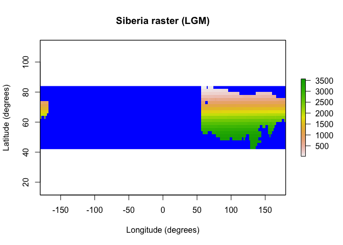

```r
raster::plot(paleopop::siberia_raster[[1]], main = "Siberia raster (LGM)",
             xlab = "Longitude (degrees)", ylab = "Latitude (degrees)",
             colNA = "blue")
```

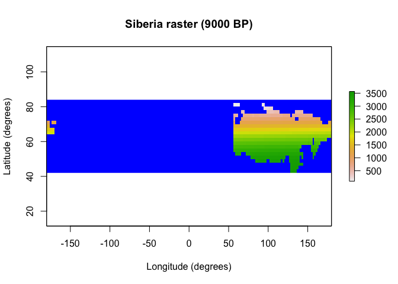

```r
raster::plot(paleopop::siberia_raster[[1001]], main = "Siberia raster (9000 BP)",
             xlab = "Longitude (degrees)", ylab = "Latitude (degrees)",
             colNA = "blue")
```

We can use this `RasterStack` object as a template to create a `PaleoRegion` object, which will set the indices of occupiable cells at each time step, and mask cells that are not occupiable at a time step (in the case of this example, because those cells are now underwater.) When we plot the `region_raster` in the `PaleoRegion` object, we see the maximum extent of the region, showing all cells that are occupiable at any time step. The `temporal_mask_raster` method generates a `RasterStack` that marks occupiable cells at each time step with a 1.

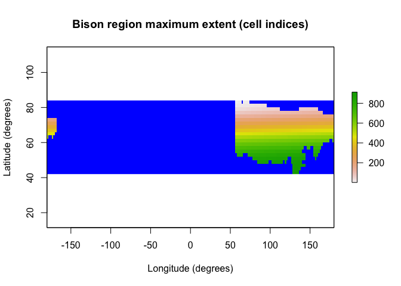

```r
region <- PaleoRegion$new(template_raster = paleopop::siberia_raster)
raster::plot(region$region_raster, main = "Bison region maximum extent (cell indices)",
             xlab = "Longitude (degrees)", ylab = "Latitude (degrees)",
             colNA = "blue")
```

# 2. Generate dispersal and carrying capacity

This part of the workflow is identical to `poems`: we create `Generator` objects to dynamically generate dispersal between grid cells, initial abundance, and carrying capacity at each point in space and time.

## 2.a. Generate dispersal matrix

We cut down on computational time during the simulations by generating ahead of time a matrix that describes the potential dispersal rates between every pairwise combination of cells in the study region. Dispersal rates are calculated using a distance-based dispersal function as well as, optionally, a conductance/friction landscape that maps out barriers to dispersal, such as ice or mountains. (We will omit the friction landscape for this example.)

```r
dispersal_gen <- DispersalGenerator$new(region = region,
                                        dispersal_max_distance = 500, # km
                                        distance_classes = seq(10, 500, 10), # divide into bins
                                        distance_scale = 1000, # sets units to km
                                        dispersal_friction = DispersalFriction$new(), # empty
                                        inputs = c("dispersal_p", "dispersal_b"),
                                        decimals = 3)
dispersal_gen$calculate_distance_data(use_longlat = TRUE) # pre-calculate matrix of distances between cells
```

[output not shown]

```r
test_dispersal <- dispersal_gen$generate(input_values =
                                                       list(dispersal_p = 0.5,
                                                            dispersal_b = 200))$dispersal_data
head(test_dispersal[[1]])
```

```
#>   target_pop source_pop emigrant_row immigrant_row dispersal_rate
#> 1          2          1            1             1          0.076
#> 2          3          1            2             1          0.065
#> 3          4          1            3             1          0.056
#> 4          9          1            4             1          0.028
#> 5         10          1            5             1          0.028
#> 6         11          1            6             1          0.026
```

## 2.b. Generate carrying capacity landscape

Here we will generate a dynamic landscape based on a raster stack of habitat suitability values (from 0, totally unsuitable, to 1, ideally suitable). `paleopop` has a spatiotemporally explicit habitat suitability `RasterStack` for Siberia from 21,000 - 9,000 years BP.

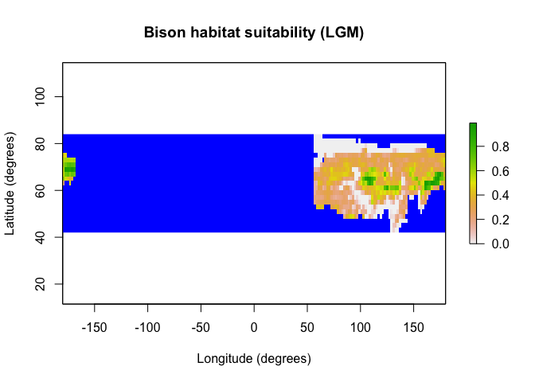

```r
raster::plot(bison_hs_raster[[1]], main = "Bison habitat suitability (LGM)",
             xlab = "Longitude (degrees)", ylab = "Latitude (degrees)",
             colNA = "blue")
```

However, PaleoPop simulations are not based on habitat suitability values. Rather, they operate on initial populations and on carrying capacities. Therefore, we need to enter these habitat suitability landscapes into a generator that can translate them into an initial abundance landscape and into a dynamic carrying capacity landscape.

To do this, we must create a `poems::Generator` object. Because every simulation has different requirements, we must set our own inputs, outputs, and generator functions to convert the inputs into the outputs. Here, we will very simply use a maximum density parameter and multiply it by the habitat suitability.

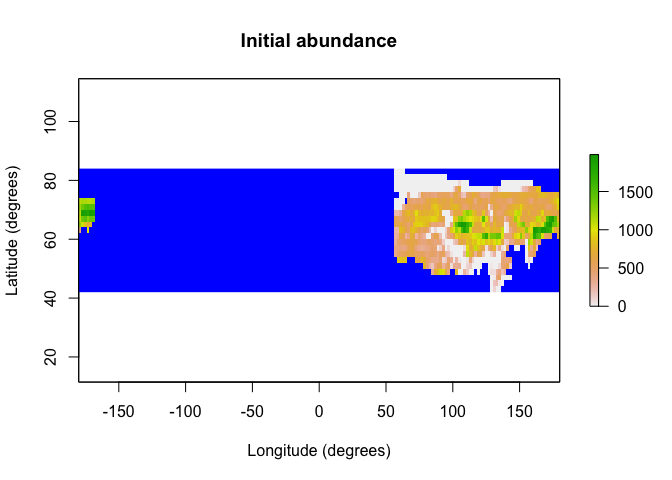

```r
# Convert the habitat suitability raster to matrix
bison_hs <- bison_hs_raster[region$region_indices]
# Create the generator
capacity_gen <- Generator$new(description = "Capacity generator",
                              example_hs = bison_hs,
                              inputs = c("density_max"),
                              outputs = c("initial_abundance", "carrying_capacity"))
# indicate that initial abundance and carrying capacity are required
capacity_gen$add_generative_requirements(list(initial_abundance = "function",
                                              carrying_capacity = "function"))
# define custom generative functions
capacity_gen$add_function_template("carrying_capacity",
                                   function_def = function(params) {
                                     round(params$density_max*params$example_hs)
                                   },
                                   call_params = c("density_max", "example_hs"))
capacity_gen$add_function_template("initial_abundance",
                                   function_def = function(params) {
                                     params$carrying_capacity[,1]
                                   },
                                   call_params = c("carrying_capacity"))
# test run
test_capacity <- capacity_gen$generate(input_values = list(density_max = 2000))
raster::plot(region$raster_from_values(test_capacity$initial_abundance), main = "Initial abundance",
             xlab = "Longitude (degrees)", ylab = "Latitude (degrees)",
             colNA = "blue")
```

# 3. Create the model template

We create a model template for simulation using the `PaleoPopModel` object. Let’s check the required attributes for the object.

```r
model_template <- PaleoPopModel$new()
model_template$model_attributes # all possible attributes
```

```
#>  [1] "coordinates"           "random_seed"           "time_steps"
#>  [4] "years_per_step"        "populations"           "initial_abundance"
#>  [7] "transition_rate"       "standard_deviation"    "compact_decomposition"
#> [10] "carrying_capacity"     "density_dependence"    "growth_rate_max"
#> [13] "dispersal_data"        "dispersal_target_k"    "harvest"
#> [16] "harvest_max"           "harvest_g"             "harvest_z"
#> [19] "harvest_max_n"         "human_density"         "abundance_threshold"
#> [22] "occupancy_threshold"   "results_selection"
```

```r
model_template$required_attributes # required attributes to run simulations
```

```
#> [1] "time_steps"         "years_per_step"     "populations"
#> [4] "initial_abundance"  "transition_rate"    "standard_deviation"
#> [7] "carrying_capacity"  "harvest"            "results_selection"
```

Initial abundance, carrying capacity, and dispersal data will be provided by the generators above. Here we will define an environmental correlation matrix so there can be spatial autocorrelation in the simulations.

```r
# Distance-based environmental correlation (via a compacted Cholesky decomposition)
env_corr <- SpatialCorrelation$new(region = region, amplitude = 0.4, breadth = 500)
correlation <- env_corr$get_compact_decomposition(decimals = 2)
```

Normally we would have spatiotemporally dynamic data on human density over time, which the prey- and predator-dependent harvest function translates into numbers of bison harvested. The harvest function in `paleopop` is defined by `harvest_z`, which determines whether harvesting is a Type II or Type III functional response, `harvest_g`, a constant added to the denominator that reduces harvest rates, and `harvest_max_n`, a ceiling on maximum prey density that can be harvested.

In the interest of simplicity for this example, we will create a matrix of constant low human density.

```r
human_density <- array(rep(0.1), c(913, 1001)) # rows = populations and columns = timesteps
```

Now we have all the components we need to build the model template, less the model attributes that will be sampled via Latin Hypercube Sampling later.

```r
model_template <- PaleoPopModel$new(
  simulation_function = "paleopop_simulator", # this is the default; made it explicit for the example
  region = region,
  # coordinates: you could use XY coordinates to define the region instead
  time_steps = 1001,
  years_per_step = 12, # generational length for bison
  populations = region$region_cells, # extracts number of population cells
  # initial_abundance: generated
  transition_rate = 1.0, # rate of transition between generations
  # standard_deviation: sampled
  compact_decomposition = correlation,
  # carrying_capacity: generated
  density_dependence = "logistic",
  # growth_rate_max: sampled
  harvest = TRUE,
  # harvest_max: sampled
  harvest_g = 0.4, # constant
  # harvest_z: sampled
  # harvest_max_n: sampled
  human_density = human_density,
  dispersal_target_k = 10, # minimum carrying capacity that attracts dispersers
  # dispersal_data: generated
  # abundance_threshold: sampled
  # initial_n: sampled
  occupancy_threshold = 1, # threshold: # of populations for the species to persist
  random_seed = 321,
  results_selection = c(
    # ema (expected minimum abundance), extirpation, occupancy, human_density,
    "abundance", "harvested"
    )
)
```

# 4. Sample model and generator parameters for each simulation

Here the workflow is the same as in `poems`: we sample along a range of values so as to create a prior, and use these to parameterize different simulations. Here, we will sample each range of values *uniformly* so as to create an *uninformative* prior, but the LHS generator object offers options for sampling along different distributions to create an *informative* prior. For the sake of this example, we will sample 10 different parameter combinations, but it is advisable to run thousands in order to fully sample the parameter space.

```r
nsims <- 10 # adjust to run your own example if desired

lhs_generator <- LatinHypercubeSampler$new()
lhs_generator$set_uniform_parameter("standard_deviation", lower = 0, upper = sqrt(0.06))
lhs_generator$set_uniform_parameter("growth_rate_max", lower = log(1.31), upper = log(2.84))
lhs_generator$set_uniform_parameter("abundance_threshold", lower = 0, upper = 500, decimals = 0)
lhs_generator$set_uniform_parameter("harvest_max", lower = 0, upper = 0.35)
lhs_generator$set_uniform_parameter("harvest_z", lower = 1, upper = 2)
lhs_generator$set_uniform_parameter("density_max", lower = 500, upper = 3250) # alias for harvest_max_n
lhs_generator$set_uniform_parameter("dispersal_p", lower = 0.05, upper = 0.25) # for the dispersal generator
lhs_generator$set_uniform_parameter("dispersal_b", lower = 65, upper = 145) # for the dispersal generator

sample_data <- lhs_generator$generate_samples(number = nsims, random_seed = 123)
sample_data$sample <- c(1:nsims)
head(sample_data)
```

```
#>   standard_deviation growth_rate_max abundance_threshold harvest_max harvest_z
#> 1         0.12844192       0.8633636                 471  0.16758685  1.510286
#> 2         0.02171397       0.5930831                 407  0.26785857  1.034352
#> 3         0.06815201       0.7415355                 323  0.33290269  1.459999
#> 4         0.23228272       0.9579419                 396  0.30130572  1.641069
#> 5         0.14845673       0.4207378                 136  0.17998030  1.854928
#> 6         0.21182926       0.5269072                 215  0.07769187  1.336949
#>   density_max dispersal_p dispersal_b sample
#> 1    619.5955  0.08969914    96.14441      1
#> 2   1505.6085  0.11640746   138.50153      2
#> 3   2241.5265  0.09977226   112.63579      3
#> 4   1915.4510  0.24870600   131.40983      4
#> 5   3237.3751  0.16170967   116.23608      5
#> 6   1045.6603  0.05308405    97.72835      6
```

# 5. Run the simulations

Here we build a simulation manager to manage the sample data, generators, and model template. The simulation manager will use the `paleopop_simulator` function to run simulations.

```r
sim_manager <- SimulationManager$new(sample_data = sample_data,
                                     model_template = model_template,
                                     generators = list(capacity_gen,
                                                       dispersal_gen),
                                     parallel_cores = parallel_cores,
                                     results_dir = output_dir)

sim_manager$results_filename_attributes <- c("sample", "results")

run_output <- sim_manager$run()
run_output$summary
```

```
#> [1] "10 of 10 sample models ran and saved results successfully"
```

The simulation log, `run_output`, can be examined for error messages and failure indices if any of the simulations fail. There is also a detailed simulation log created in the output directory.

# 6. Examine the results

We can explore the results of the simulations using the convenient wrapper of the `PaleoPopResults` object. Each `PaleoPopResults` object can hold the result of one simulation, and it can generate outputs that were not specified in the results selection above, such as extirpation times for each population.

```r
results1 <- PaleoPopResults$new(
  results = readRDS(paste0(output_dir, "/sample_1_results.RData")),
  region = region, time_steps = 1001
  )
head(results1$extirpation)
```

```
#> [1] 1 1 1 1 2 2
```

We can also use a `PaleoPopResults` object as a kind of template for the `ResultsManager`, an object that can calculate summary metrics for many results all at once. As with the generators, we must define our own custom metrics functions, because each *in silico* experiment calls for a different set of metrics to summarize the outputs. We can use the metrics generated by the `PaleoPopResults` object as the basis for our custom summary metrics.

```r
results_model <- PaleoPopResults$new(region = region, time_steps = 1001, trend_interval = 1:10)
metrics_manager <- ResultsManager$new(simulation_manager = sim_manager,
                                      simulation_results = results_model,
                                      generators = NULL) # don't need generators
metrics_manager$summary_metrics <- c("abundance_trend", "extinction_time")
metrics_manager$summary_functions <- list()

metrics_manager$summary_functions$extinction_time <- function(simulation_results) {
  extinction_time <- -12*(1001 - simulation_results$all$extirpation)-9001 # converts timestep to years BP
  if (is.na(extinction_time)) {
    extinction_time <- -9001 # if NA, then it survived to the end of the simulation
  }
  return(extinction_time)
}

metrics_manager$summary_functions$abundance_trend <- function(simulation_results) {
  abundance_trend <- simulation_results$all$abundance_trend
  return(abundance_trend) # this will use the trend interval specified above
}

gen_log <- metrics_manager$generate(results_dir = output_dir)
```

You can examine the log for the summary metrics calculation to browse error messages for failed calculations.

Now that we’ve calculated some summary metrics, based on outputs from `PaleoPopResults` like extinction time and abundance trend, we can examine the simulation results. Here I show the simulated extinction times.

```r
metrics_manager$summary_metric_data$extinction_time
```

```
#>  [1] -20977 -20809 -11485 -13825  -9001 -11485 -13825  -9001  -9001  -9001
```

Both of these summary metrics, abundance trend over the first ten time steps and extinction time, could be a suitable metric to converge toward a validation target.

From here, you may continue with the `poems` workflow, as explained in the `poems` [vignette](https://cran.r-project.org/web//packages/poems/vignettes/thylacine_example.pdf), creating a `Validator` object for pattern-oriented modeling to validate the results of the simulation.